# Supplementary Materials: It matters who is spreading monkeypox

Jonathan Smith, PhD, MPH

2022-07-24

Written in R version 4.1.2.

## Background

We assume the number of secondary cases produced from each infectious case is distributed according to a negative binomial distribution with mean $R_0$ (the basic reproductive number) and dispersion parameter $k$. The parameter $k$ quantifies the degree of individual heterogeneity by measuring overdispersion in the distribution (e.g., higher than expected variation). For a given $R<1$, smaller values of $k$ ($k<<1$) suggest increased heterogeneity in the number of secondary cases between individual index cases. As $k$ increases, transmission becomes more uniform and centered around the mean, $R_0$.

## Proportion of secondary cases attributed to the proportion of infectious cases

Lloyd-Smith *et al.* (L-S) ([supplementary information 2.2.5](https://static-content.springer.com/esm/art%3A10.1038%2Fnature04153/MediaObjects/41586_2005_BFnature04153_MOESM1_ESM.pdf)) propose a distribution for describing transmission based from the distribution of the individual reproduction number $\nu$:
$$F_\mathrm{trans}(x) = \frac{1}{R_0} \int_0^x
u\, f_\nu (u) \, du$$
This gives the cumulative distribution function (CDF) in terms of the individual reproduction number density $f_\nu$, as the proportion of all transmission due to infectious individuals with reproduction number $\nu <x$.

In the specific case when $\nu$ is gamma distributed with shape parameter $k>0$ and rate parameter $k/R_0$, where $R_0$ is the mean (expected) individual reproduction number, we have
$$f_\nu(u) =
\frac{k^k}{R_0^k \, \Gamma(k)} u^{k-1} e^{-ku/R_0}$$
It follows that
$$\begin{eqnarray*} f_\mathrm{trans}(x)
= F'_\mathrm{trans}(x)
&=& \frac{1}{R_0} x f_\nu(x)
\\
&=& \frac{k^k}{R_0^{k+1} \, \Gamma(k)} x^k e^{-kx/R_0}
\\
&=& \frac{k^{k+1}}{R_0^{k+1} \, \Gamma(k+1)} x^k e^{-kx/R_0}
\\
&\sim & \mathrm{Gamma}(k+1, k/R_0)
\end{eqnarray*}$$

The rate parameter remains the same and the shape parameter increases by 1.

To calculate $t_p$, the expected proportion of transmission due to the most infectious $100p$% of cases, we first find the $(1-p)$th centile of the individual reproduction number, $x_p = F^{-1}_\nu(1-p)$, then calculate $t_p = 1-F_\mathrm{trans}(x_p)$. As both random variables are gamma distributed, this is implemented in R via the qgamma ($F^{-1}$) and pgamma ($F$) functions.

```r
propinfection <- function(R, k, prop){
  xp <- qgamma(1 - prop, shape = k, rate = k/R)
  tp <- 1 - pgamma(xp, shape = k+1, rate = k/R)
  return(tp)
}
```

## The relationship between $p$ and $t_p$

Parameterizing by $x_p$, and noting that $p=1-F_\nu(x_p)$, the first derivative is
$$\frac{d t_p}{dp} =
\frac{dt_p/dx_p}{dp/dx_p}
= \frac{-F'_\mathrm{trans}(x_p)}{-F'_\nu(x_p)} =
\frac{R_0^{-1} x_p f_\nu(x_p)}{f_\nu(x_p)} = \frac{x_p}{R_0} >
0$$
which confirms that $t_p$ is an increasing function of $p$. When $x_p=0$, $(p, t_p) = (1,1)$ at which the point the derivative is zero (horizontal tangent). Similarly, when $x_p=+\infty$, $(p, t_p) = (0,0)$ at which the point the derivative is infinite (vertical tangent).

The second derivative is negative implying concavity of the graph of $t_p$ as a function of $p$.
$$\frac{d^2 t_p}{dp^2}
= \frac{d}{dx_p} \left(\frac{d t_p}{dp}\right) \times \frac{d x_p}{dp}
= \frac{1}{R_0} \times \frac{1}{dp/dx_p} = - \frac{1}{R_0 f_\nu(x_p)}
<0$$
These properties can be seen in Figure 1A:

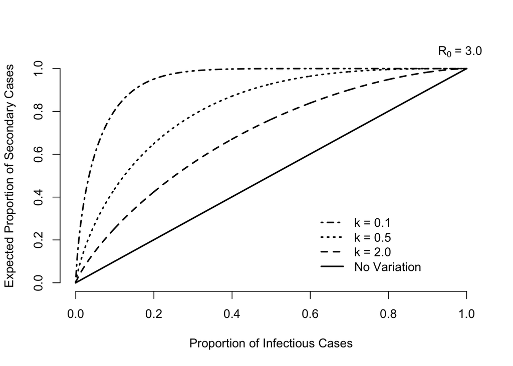

```r
xx <- seq(0, 1, 0.001)
k <- c(0.1, 0.5, 2, 100000) # 100000 -> ~infty (homogenous transmission)
plotdata <- cbind(xx,
                  propinfection(R = 3, k = k[1], xx),
                  propinfection(R = 3, k = k[2], xx),
                  propinfection(R = 3, k = k[3], xx),
                  propinfection(R = 3, k = k[4], xx))


plot(plotdata[,1], plotdata[,2], type = "l", bty = "n",
     xlab = "Proportion of Infectious Cases",
     ylab = "Expected Proportion of Secondary Cases",
     lwd = 2, lty = 4)
lines(plotdata[,1], plotdata[,3], lty = 3, lwd = 2)
lines(plotdata[,1], plotdata[,4], lty = 2, lwd = 2)
lines(plotdata[,1], plotdata[,5], lty = 1, lwd = 2)
legend(x = 0.6, y = 0.35, c("k = 0.1", "k = 0.5", "k = 2.0", "No Variation"),
       lty = 4:1, bty = "n", lwd = 2)
mtext(bquote(R[0]~"= 3.0"), adj = 1)
```

## Final Outbreak Size

Let $Y$ represent the sum of all cases in a transmission chain (including the index case), resulting in a final outbreak size (Dwass, 1969). Using branching process theory, the distribution of the total number of secondary infections in a single transmission chain (including the index case at generation) can be defined by the probability generating function (pgf) yielding the implicit relationship (Yan 2008):

$$G_Y(s) = sG_Z((G_Y(s))$$
We can treat this as $G_Y(s) = \sum_{y=1}^\infty q_ys^y$, where $q_y = P(Y=y)$, allowing us to extract the probability (Becker 1974; Blumberg 2014):

$$P(Y=y)=\frac{1}{y!}\frac{d_yG_Y(s)}{ds^y}\Bigg|_{s=0}$$
Where $Y=1, 2, 3\dots$

Plugging in the negative binomial distribution yields (see Smith 2022 (supplementary information, section 4) and Blumberg 2012)
$$P(Y=y)=\bigg(\frac{n}{y}\bigg)\frac{\Gamma(ky+y-n)}{\Gamma(ky)(y-n)!}\frac{(\frac{R_0}{k})^{y-n}}{(1+\frac{R_0}{k})^{ky+y-n}}$$
Where $n$ represents the number of index cases initiating the outbreak and $Y=1, 2, 3\dots$.

The this is implemented in R software by exponentiating the log-likelihood (for computational ease):

```r
outbreakprob <- function(y, R, k){
  l <- lgamma(k * y + (y - 1)) - (lgamma(k * y) + lgamma(y + 1)) + (y - 1) * log(R / k) - (k * y + (y - 1)) * log(1 + R / k)
  return(exp(l))
}
```

Figure 1B is generated with the following code:

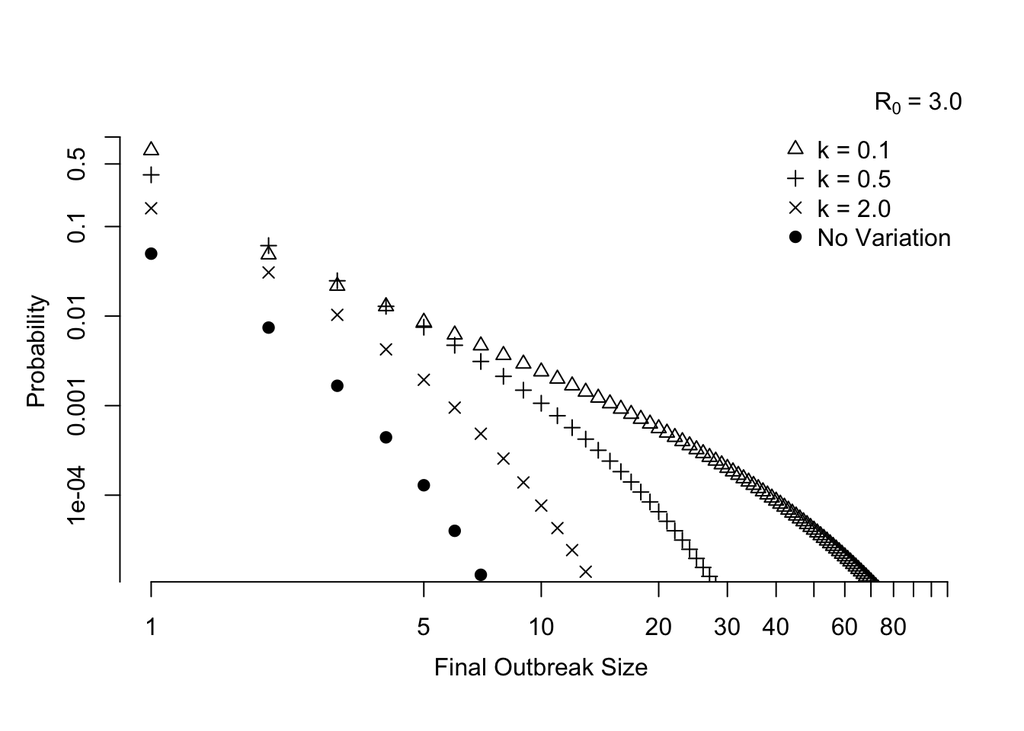

```r
R <- 3
maxoutbreak <- 100
outbrk_prob1 <- outbreakprob(1:maxoutbreak, R, k[1])
outbrk_prob2 <- outbreakprob(1:maxoutbreak, R, k[2])
outbrk_prob3 <- outbreakprob(1:maxoutbreak, R, k[3])
outbrk_prob4 <- outbreakprob(1:maxoutbreak, R, k[4])

xx <- seq(0, maxoutbreak, by = 0.01)
maxrange <- seq(1, maxoutbreak, 1)

plot(log(range(1, maxoutbreak)), range(-11,0), type = 'n', xlab = '', ylab = '', axes = F)
  points(log(maxrange), log(outbrk_prob1), col = 1, pch=2, cex=1)
  points(log(maxrange), log(outbrk_prob2), col = 1, pch=3, cex=1)
  points(log(maxrange), log(outbrk_prob3), col = 1, pch=4, cex=1)
  points(log(maxrange), log(outbrk_prob4), col = 1, pch=19, cex=1)
  axis(side=1, at=log(c(1, 5, seq(10, maxoutbreak + 10, b = 10))), c(1, 5, seq(10, maxoutbreak + 10, b = 10)))
  axis(side=2, at=log(c(1/100000, 1/10000, 1/1000, 1/100, 1/10, 1/2, 1)), c(1/100000, 1/10000, 1/1000, 1/100, 1/10, 1/2, 1))
  mtext(side=1, 'Final Outbreak Size', padj=4)
  mtext(side=2, 'Probability', padj=-4)
  legend('topright', c("k = 0.1", "k = 0.5", "k = 2.0", "No Variation"),
         pch=c(2:4, 19), cex=1, bty="n")
  mtext(bquote(R[0]~"= 3.0"), adj = 1)
```

## Thanks

Special thanks to Dr. Andrew Hill for providing mathematical oversight into this analysis.

## References

1. Lloyd-Smith, JO, *et al*. Superspreading and the effect of individual variation on disease emergence, Nature 438, 355–359 (2005)
2. Yan, P. Distribution Theory, Stochastic Processes and Infectious Disease Modelling, pages 229. Springer Berlin Heidelberg, Berlin, Heidelberg, 2008.
3. Becker, N. On parametric estimation for mortal branching processes. Biometrika, 61(3):393, 1974.
4. Dwass, M. The total progeny in a branching process and a related random walk. Journal of Applied Probability, 6(3):682, 1969.
5. Blumberg S and Lloyd-Smith JO. Inference of r0 and transmission heterogeneity from the size distribution of stuttering chains. PLoS Comput Biol., 5(9):393, 2013.
6. Smith, JP, *et al*. A cluster-based method to quantify individual heterogeneity in tuberculosis transmission. Epidemiology 33, 217–227. 2022